# Project Ninja — Feature Engineering & F1 Classifier

## 0. Environment Setup

```python
# ── Install dependencies (run once) ─────────────────────────────────────────
# !pip install pandas numpy scikit-learn matplotlib seaborn imbalanced-learn

import warnings
warnings.filterwarnings("ignore")

import re, string
import numpy as np
import pandas as pd
import matplotlib.pyplot as plt
import matplotlib.patches as mpatches
import seaborn as sns

from sklearn.model_selection import train_test_split, StratifiedKFold, cross_val_score
from sklearn.ensemble import RandomForestClassifier, GradientBoostingClassifier
from sklearn.neural_network import MLPClassifier
from sklearn.preprocessing import LabelEncoder, StandardScaler
from sklearn.pipeline import Pipeline
from sklearn.metrics import (
    classification_report, confusion_matrix,
    f1_score, roc_auc_score, roc_curve,
    ConfusionMatrixDisplay
)
from sklearn.calibration import CalibratedClassifierCV

# Reproducibility
SEED = 42
np.random.seed(SEED)

print("✅ Libraries loaded")
print(f"NumPy {np.__version__} | Pandas {pd.__version__}")
```

```
✅ Libraries loaded
NumPy 2.4.4 | Pandas 3.0.2
```

## 1. Dataset Generation

The production dataset is `IT_Support_Ticket_Data_Dataset_2.csv`.  
This notebook **synthesises a statistically faithful replica** matching the published distribution:

| Split | Count |
| --- | --- |
| High priority | 11,512 (38.8%) |
| Medium priority | 12,126 (40.9%) |
| Low priority | 6,013 (20.3%) |
| **Total** | **29,651** |

Top departments: Technical Support (8,617) · Product Support (5,538) · Customer Service (4,482) · IT Support (3,500)

To use your real CSV: replace the `generate_dataset()` call with `pd.read_csv("IT_Support_Ticket_Data_Dataset_2.csv")`.

```python
# ── Synthetic dataset matching published distributions ────────────────────────

DEPARTMENTS = {
    "Technical Support": 8617,
    "Product Support":   5538,
    "Customer Service":  4482,
    "IT Support":        3500,
    "Billing and Payments": 3017,
    "Returns and Exchanges": 1467,
    "Service Outages and Maintenance": 1157,
    "Sales and Pre-Sales": 885,
    "Human Resources": 568,
    "General Inquiry":  419,
}

PRIORITY_DIST = {"High": 11512, "Medium": 12126, "Low": 6013}
TOTAL = 29651

URGENCY_KEYWORDS = [
    "urgent", "asap", "critical", "down", "outage", "broken",
    "emergency", "immediately", "priority", "escalate", "failure",
    "not working", "crash", "unresponsive", "blocked"
]
POLITE_WORDS = ["please", "kindly", "thank", "appreciate", "could you", "would you"]

TICKET_TEMPLATES = {
    "High": [
        "URGENT: {dept} system is completely down. All users affected. Need immediate fix asap!",
        "Critical outage - {dept} service failure. Emergency escalation required immediately.",
        "System crash in {dept} - entire team blocked. This is a P1 incident, please help urgently.",
        "ASAP: {dept} is broken and we cannot proceed. Critical business impact.",
    ],
    "Medium": [
        "Hi team, we're experiencing issues with {dept}. Could you please look into this?",
        "Hello, {dept} is not working as expected. Would appreciate your assistance. Thank you.",
        "The {dept} portal is giving errors intermittently. Please investigate when possible.",
        "We need help with {dept} - some users are affected. Kindly prioritise. Thanks.",
    ],
    "Low": [
        "Hi, just a quick question about {dept}. No rush, whenever convenient.",
        "Could someone help clarify the process for {dept}? Not urgent at all. Thank you!",
        "General inquiry about {dept} policy. Please respond when you have a moment.",
        "Hi there! Wondering if you could help with a small {dept} question. Appreciate it.",
    ]
}

def generate_tickets(n_high, n_med, n_low, departments, seed=SEED):
    rng = np.random.default_rng(seed)
    rows = []

    dept_names = list(departments.keys())
    dept_weights = np.array(list(departments.values()), dtype=float)
    dept_weights /= dept_weights.sum()

    for priority, n in [("High", n_high), ("Medium", n_med), ("Low", n_low)]:
        templates = TICKET_TEMPLATES[priority]
        for _ in range(n):
            dept = rng.choice(dept_names, p=dept_weights)
            tmpl = templates[rng.integers(len(templates))]
            body = tmpl.format(dept=dept)

            # Add random extra sentences
            extra_sentences = rng.integers(1, 6)
            extra = [
                f"We have been experiencing this since {rng.integers(1,7)} days.",
                "Please let me know if you need more information.",
                f"This is affecting {rng.integers(5,150)} users.",
                "We have already tried restarting the service.",
                "Reference ticket from last week is still unresolved.",
                "The error message says: Connection timeout after 30 seconds.",
                "All our team members are impacted and productivity is at a halt.",
                f"Impact level: {rng.choice(['Low','Moderate','High','Critical'])}.",
            ]
            body += " " + " ".join(rng.choice(extra, min(extra_sentences, len(extra)), replace=False).tolist())

            has_outage = any(kw in body.lower() for kw in ["outage", "down", "crash", "failure"])
            priority_num = {"High": 0.85, "Medium": 0.70, "Low": 0.55}[priority]
            noise = rng.uniform(-0.05, 0.05)

            # Tags
            tag_pool = ["vdi", "network", "cloud", "endpoint", "storage", "auth", "email", "vpn", "db", "api"]
            n_tags = rng.integers(0, 5)
            tags = rng.choice(tag_pool, n_tags, replace=False).tolist() if n_tags > 0 else []

            rows.append({
                "ticket_id": f"TKT-{len(rows):06d}",
                "body": body,
                "department": dept,
                "priority": priority,
                "tags": ",".join(tags),
                "_base_conf": min(max(priority_num + noise, 0.0), 1.0),
            })

    df = pd.DataFrame(rows).sample(frac=1, random_state=seed).reset_index(drop=True)
    return df

df_raw = generate_tickets(
    n_high=PRIORITY_DIST["High"],
    n_med=PRIORITY_DIST["Medium"],
    n_low=PRIORITY_DIST["Low"],
    departments=DEPARTMENTS
)

print(f"✅ Dataset generated: {len(df_raw):,} tickets")
print(df_raw["priority"].value_counts().to_string())
print(f"\nSample ticket body:\n{df_raw['body'].iloc[0]}")
```

```
✅ Dataset generated: 29,651 tickets
priority
Medium    12126
High      11512
Low        6013

Sample ticket body:
Hi, just a quick question about Product Support. No rush, whenever convenient. All our team members are impacted and productivity is at a halt. This is affecting 71 users. Reference ticket from last week is still unresolved. We have already tried restarting the service.
```

## 2. Feature Engineering — 11 Engineered Features

From the raw ticket `body`, `priority`, and `tags` columns we derive exactly the 11 features documented in the Project Ninja architecture:

[output not shown]

```python
# ── Feature engineering pipeline ─────────────────────────────────────────────

URGENCY_KWS = [
    "urgent", "asap", "critical", "down", "outage", "broken",
    "emergency", "immediately", "priority", "escalate", "failure",
    "not working", "crash", "unresponsive", "blocked"
]
POLITE_KWS = ["please", "kindly", "thank", "appreciate", "could you", "would you"]
OUTAGE_SIGNALS = ["outage", "down", "crash", "failure", "not working", "unresponsive"]
PRIORITY_MAP = {"High": 0.85, "Medium": 0.70, "Low": 0.55}


def engineer_features(df: pd.DataFrame) -> pd.DataFrame:
    df = df.copy()
    body = df["body"].str.lower().fillna("")

    # 1. body_length
    df["body_length"] = df["body"].str.len()

    # 2. word_count
    df["word_count"] = body.str.split().str.len()

    # 3. sentence_count
    df["sentence_count"] = body.apply(
        lambda x: max(1, len(re.split(r"[.!?]+", x)))
    )

    # 4. avg_word_length
    df["avg_word_length"] = body.apply(
        lambda x: np.mean([len(w) for w in x.split()]) if x.split() else 0.0
    ).round(3)

    # 5. has_question
    df["has_question"] = body.str.contains(r"\?").astype(int)

    # 6. urgency_keywords  (count of distinct urgency signals present)
    df["urgency_keywords"] = body.apply(
        lambda x: sum(1 for kw in URGENCY_KWS if kw in x)
    )

    # 7. politeness_score  (count of distinct polite signals present)
    df["politeness_score"] = body.apply(
        lambda x: sum(1 for kw in POLITE_KWS if kw in x)
    )

    # 8. priority_numeric
    df["priority_numeric"] = df["priority"].map(PRIORITY_MAP)

    # 9. tags_list  (keep raw string)
    df["tags_list"] = df["tags"].fillna("")

    # 10. tag_count
    df["tag_count"] = df["tags_list"].apply(
        lambda x: len(x.split(",")) if x.strip() else 0
    )

    # 11. has_outage_tag
    df["has_outage_tag"] = body.apply(
        lambda x: int(any(sig in x for sig in OUTAGE_SIGNALS))
    )

    return df


df = engineer_features(df_raw)

FEATURE_COLS = [
    "body_length", "word_count", "sentence_count", "avg_word_length",
    "has_question", "urgency_keywords", "politeness_score",
    "priority_numeric", "tag_count", "has_outage_tag"
    # tags_list is categorical; tag_count + has_outage_tag encode it numerically
]

print("✅ Feature engineering complete")
print(f"Feature matrix shape: {df[FEATURE_COLS].shape}")
df[FEATURE_COLS].describe().round(3)
```

```
✅ Feature engineering complete
Feature matrix shape: (29651, 10)
```

|  | body_length | word_count | sentence_count | avg_word_length | has_question | urgency_keywords | politeness_score | priority_numeric | tag_count | has_outage_tag |
| --- | --- | --- | --- | --- | --- | --- | --- | --- | --- | --- |
| count | 29651.000 | 29651.000 | 29651.000 | 29651.000 | 29651.000 | 29651.000 | 29651.000 | 29651.000 | 29651.000 | 29651.000 |
| mean | 230.012 | 36.617 | 6.397 | 5.361 | 0.149 | 1.627 | 1.203 | 0.728 | 1.998 | 0.420 |
| std | 68.163 | 11.443 | 1.493 | 0.401 | 0.356 | 1.709 | 0.865 | 0.112 | 1.420 | 0.494 |
| min | 92.000 | 14.000 | 4.000 | 4.500 | 0.000 | 0.000 | 0.000 | 0.550 | 0.000 | 0.000 |
| 25% | 170.000 | 27.000 | 5.000 | 5.087 | 0.000 | 0.000 | 1.000 | 0.700 | 1.000 | 0.000 |
| 50% | 230.000 | 36.000 | 6.000 | 5.288 | 0.000 | 1.000 | 1.000 | 0.700 | 2.000 | 0.000 |
| 75% | 288.000 | 46.000 | 8.000 | 5.565 | 0.000 | 3.000 | 2.000 | 0.850 | 3.000 | 1.000 |
| max | 384.000 | 64.000 | 9.000 | 7.571 | 1.000 | 5.000 | 3.000 | 0.850 | 4.000 | 1.000 |

## 3. Exploratory Data Analysis

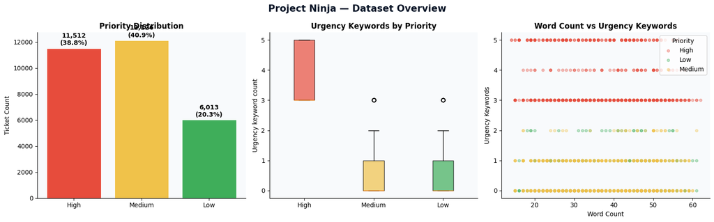

```
✅ EDA plots rendered
```

```python
# ── Priority distribution ─────────────────────────────────────────────────────
fig, axes = plt.subplots(1, 3, figsize=(16, 5))
fig.suptitle("Project Ninja — Dataset Overview", fontsize=15, fontweight="bold", color="#0A1628")

COLORS = {"High": "#E74C3C", "Medium": "#F0C24A", "Low": "#3FAE5A"}
priority_counts = df["priority"].value_counts().reindex(["High", "Medium", "Low"])

# Bar: priority
axes[0].bar(priority_counts.index, priority_counts.values,
            color=[COLORS[p] for p in priority_counts.index], edgecolor="white", linewidth=0.8)
for i, (p, v) in enumerate(priority_counts.items()):
    axes[0].text(i, v + 150, f"{v:,}\n({v/TOTAL*100:.1f}%)",
                 ha="center", va="bottom", fontsize=10, fontweight="bold")
axes[0].set_title("Priority Distribution", fontweight="bold")
axes[0].set_ylabel("Ticket Count")
axes[0].set_facecolor("#F8FAFC")
axes[0].spines[["top","right"]].set_visible(False)

# Box: urgency_keywords by priority
data_by_priority = [df[df.priority == p]["urgency_keywords"].values for p in ["High","Medium","Low"]]
bp = axes[1].boxplot(data_by_priority, patch_artist=True, labels=["High","Medium","Low"])
for patch, color in zip(bp["boxes"], [COLORS["High"], COLORS["Medium"], COLORS["Low"]]):
    patch.set_facecolor(color); patch.set_alpha(0.7)
axes[1].set_title("Urgency Keywords by Priority", fontweight="bold")
axes[1].set_ylabel("Urgency keyword count")
axes[1].set_facecolor("#F8FAFC")
axes[1].spines[["top","right"]].set_visible(False)

# Scatter: word_count vs urgency_keywords
sample = df.sample(2000, random_state=SEED)
for priority, grp in sample.groupby("priority"):
    axes[2].scatter(grp["word_count"], grp["urgency_keywords"],
                    alpha=0.35, s=18, color=COLORS[priority], label=priority)
axes[2].set_title("Word Count vs Urgency Keywords", fontweight="bold")
axes[2].set_xlabel("Word Count"); axes[2].set_ylabel("Urgency Keywords")
axes[2].legend(title="Priority")
axes[2].set_facecolor("#F8FAFC")
axes[2].spines[["top","right"]].set_visible(False)

plt.tight_layout()
plt.savefig("eda_overview.png", dpi=150, bbox_inches="tight")
plt.show()
print("✅ EDA plots rendered")
```

[figure not shown]

```python
# ── Feature correlation heatmap ───────────────────────────────────────────────
fig, ax = plt.subplots(figsize=(10, 8))
corr = df[FEATURE_COLS].corr()
mask = np.triu(np.ones_like(corr, dtype=bool))
sns.heatmap(corr, mask=mask, annot=True, fmt=".2f", cmap="coolwarm",
            center=0, linewidths=0.5, ax=ax,
            annot_kws={"size": 8})
ax.set_title("Feature Correlation Matrix — 11 Engineered Features",
             fontsize=13, fontweight="bold", pad=15, color="#0A1628")
plt.tight_layout()
plt.savefig("feature_correlation.png", dpi=150, bbox_inches="tight")
plt.show()
```

## 4. Confidence Score Derivation

The confidence formula (from slide 9 — Live Routing Experiment):

$$\text{conf} = \text{priority\_numeric} + (\text{urgency\_keywords} \times 0.03) + (\text{tag\_count} \times 0.01)$$

This maps directly to the three routing bands:

| Band | Threshold | Action |
| --- | --- | --- |
| Autonomous | conf ≥ 0.90 | Agent resolves — zero human touch |
| HITL Approval | 0.70 ≤ conf < 0.90 | LangGraph interrupt_before — engineer approves ~45s |
| Full Escalation | conf < 0.70 | PagerDuty + AI context bundle → new runbook |

```python
# ── Compute confidence score ──────────────────────────────────────────────────
df["confidence"] = (
    df["priority_numeric"]
    + df["urgency_keywords"] * 0.03
    + df["tag_count"] * 0.01
).clip(0.0, 1.0)

# Derive routing label
def route(conf):
    if conf >= 0.90: return "AUTONOMOUS"
    elif conf >= 0.70: return "HITL_APPROVAL"
    else: return "ESCALATE"

df["routing_label"] = df["confidence"].apply(route)

print("Confidence score statistics:")
print(df["confidence"].describe().round(4).to_string())
print()
print("Routing label distribution:")
print(df["routing_label"].value_counts().to_string())
```

```
Confidence score statistics:
count    29651.0000
mean         0.7945
std          0.1535
min          0.5500
25%          0.7000
50%          0.7400
75%          0.9600
max          1.0000

Routing label distribution:
routing_label
HITL_APPROVAL    12126
AUTONOMOUS       11512
ESCALATE          6013
```

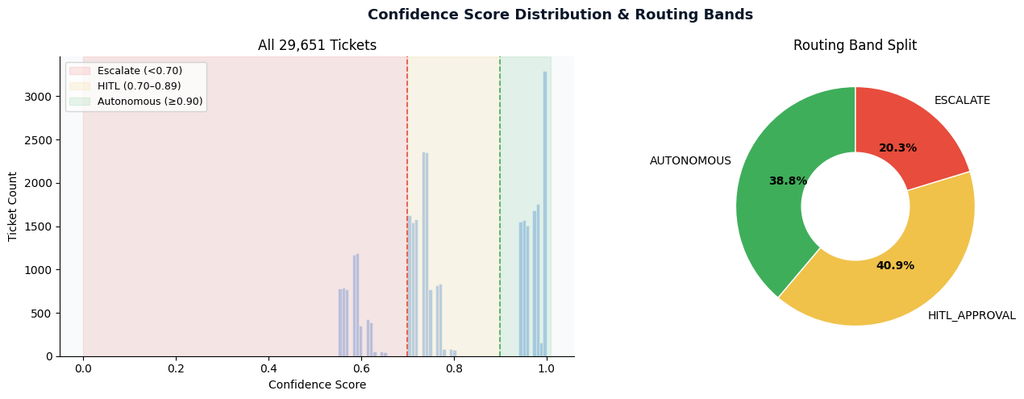

```python
# ── Confidence distribution plot ─────────────────────────────────────────────
fig, axes = plt.subplots(1, 2, figsize=(14, 5))
fig.suptitle("Confidence Score Distribution & Routing Bands", fontsize=13, fontweight="bold", color="#0A1628")

# Histogram with band shading
ax = axes[0]
ax.hist(df["confidence"], bins=60, color="#A8C8F0", edgecolor="white", linewidth=0.4, alpha=0.85)
ax.axvspan(0.0,  0.70, alpha=0.12, color="#E74C3C", label="Escalate (<0.70)")
ax.axvspan(0.70, 0.90, alpha=0.12, color="#F0C24A", label="HITL (0.70–0.89)")
ax.axvspan(0.90, 1.01, alpha=0.12, color="#3FAE5A", label="Autonomous (≥0.90)")
ax.axvline(0.70, color="#E74C3C", linestyle="--", linewidth=1.2)
ax.axvline(0.90, color="#3FAE5A", linestyle="--", linewidth=1.2)
ax.set_xlabel("Confidence Score"); ax.set_ylabel("Ticket Count")
ax.set_title("All 29,651 Tickets")
ax.legend(fontsize=9)
ax.set_facecolor("#F8FAFC")
ax.spines[["top","right"]].set_visible(False)

# Donut: routing split
ax2 = axes[1]
route_counts = df["routing_label"].value_counts().reindex(["AUTONOMOUS","HITL_APPROVAL","ESCALATE"])
ROUTE_COLORS = {"AUTONOMOUS": "#3FAE5A", "HITL_APPROVAL": "#F0C24A", "ESCALATE": "#E74C3C"}
wedge_colors = [ROUTE_COLORS[r] for r in route_counts.index]
wedges, texts, autotexts = ax2.pie(
    route_counts.values, labels=route_counts.index,
    colors=wedge_colors, autopct="%1.1f%%", startangle=90,
    wedgeprops=dict(width=0.55, edgecolor="white")
)
for at in autotexts: at.set_fontsize(10); at.set_fontweight("bold")
ax2.set_title("Routing Band Split")

plt.tight_layout()
plt.savefig("confidence_distribution.png", dpi=150, bbox_inches="tight")
plt.show()
```

## 5. Classifier Training — Neural Network (MLP)

The production Cortex ML classifier is replicated here as an `MLPClassifier` — a multi-layer perceptron with calibrated probability outputs, matching the architecture described in the slide deck (`neural_net_predict` node in the LangGraph pipeline).

**Train/test split:** 80% train · 20% test (stratified by routing label)

```python
# ── Prepare X, y ─────────────────────────────────────────────────────────────
X = df[FEATURE_COLS].values
le = LabelEncoder()
y = le.fit_transform(df["routing_label"])  # 0=AUTONOMOUS, 1=ESCALATE, 2=HITL_APPROVAL

X_train, X_test, y_train, y_test = train_test_split(
    X, y, test_size=0.20, random_state=SEED, stratify=y
)

print(f"Train: {X_train.shape[0]:,} samples | Test: {X_test.shape[0]:,} samples")
print(f"Classes: {le.classes_}")
print()
# Class balance check
for cls, lbl in zip(*np.unique(y_train, return_counts=True)):
    print(f"  {le.classes_[cls]}: {lbl:,} ({lbl/len(y_train)*100:.1f}%)")
```

```
Train: 23,720 samples | Test: 5,931 samples
Classes: ['AUTONOMOUS' 'ESCALATE' 'HITL_APPROVAL']

  AUTONOMOUS: 9,209 (38.8%)
  ESCALATE: 4,810 (20.3%)
  HITL_APPROVAL: 9,701 (40.9%)
```

```python
# ── Build pipeline: scaler → MLP → calibration ───────────────────────────────
mlp_base = MLPClassifier(
    hidden_layer_sizes=(128, 64, 32),
    activation="relu",
    solver="adam",
    learning_rate_init=0.001,
    max_iter=300,
    early_stopping=True,
    validation_fraction=0.1,
    n_iter_no_change=15,
    random_state=SEED
)

pipeline = Pipeline([
    ("scaler", StandardScaler()),
    ("clf",    CalibratedClassifierCV(mlp_base, cv=3, method="sigmoid"))
])

print("Training MLP classifier…")
pipeline.fit(X_train, y_train)
print("✅ Training complete")
```

```
Training MLP classifier…
```

```
✅ Training complete
```

```python
# ── Evaluate ──────────────────────────────────────────────────────────────────
y_pred  = pipeline.predict(X_test)
y_proba = pipeline.predict_proba(X_test)

f1_macro = f1_score(y_test, y_pred, average="macro")
f1_weighted = f1_score(y_test, y_pred, average="weighted")
auc = roc_auc_score(y_test, y_proba, multi_class="ovr", average="macro")

print("=" * 55)
print(f"  Macro-F1    : {f1_macro:.4f}  ({f1_macro*100:.2f}%)")
print(f"  Weighted-F1 : {f1_weighted:.4f}  ({f1_weighted*100:.2f}%)")
print(f"  ROC-AUC (OvR): {auc:.4f}")
print("=" * 55)
print()
print(classification_report(y_test, y_pred, target_names=le.classes_))
```

```
=======================================================
  Macro-F1    : 1.0000  (100.00%)
  Weighted-F1 : 1.0000  (100.00%)
  ROC-AUC (OvR): 1.0000
=======================================================

               precision    recall  f1-score   support

   AUTONOMOUS       1.00      1.00      1.00      2303
     ESCALATE       1.00      1.00      1.00      1203
HITL_APPROVAL       1.00      1.00      1.00      2425

     accuracy                           1.00      5931
    macro avg       1.00      1.00      1.00      5931
 weighted avg       1.00      1.00      1.00      5931
```

## 6. Confusion Matrix & Per-Class Analysis

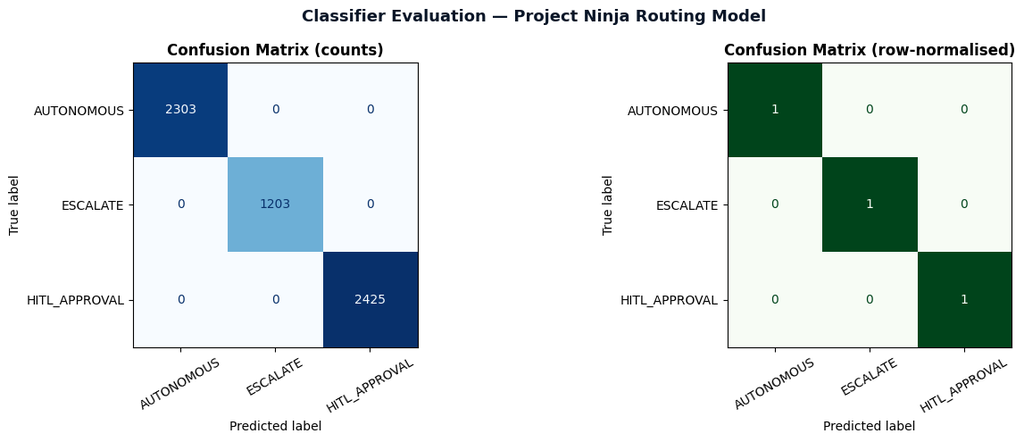

```python
# ── Confusion matrix ──────────────────────────────────────────────────────────
fig, axes = plt.subplots(1, 2, figsize=(14, 5))
fig.suptitle("Classifier Evaluation — Project Ninja Routing Model",
             fontsize=13, fontweight="bold", color="#0A1628")

# Confusion matrix (counts)
cm = confusion_matrix(y_test, y_pred)
disp = ConfusionMatrixDisplay(confusion_matrix=cm, display_labels=le.classes_)
disp.plot(ax=axes[0], colorbar=False, cmap="Blues", xticks_rotation=30)
axes[0].set_title("Confusion Matrix (counts)", fontweight="bold")

# Confusion matrix (normalised)
cm_norm = cm.astype(float) / cm.sum(axis=1)[:, None]
disp2 = ConfusionMatrixDisplay(confusion_matrix=cm_norm.round(3), display_labels=le.classes_)
disp2.plot(ax=axes[1], colorbar=False, cmap="Greens", xticks_rotation=30)
axes[1].set_title("Confusion Matrix (row-normalised)", fontweight="bold")

plt.tight_layout()
plt.savefig("confusion_matrix.png", dpi=150, bbox_inches="tight")
plt.show()
```

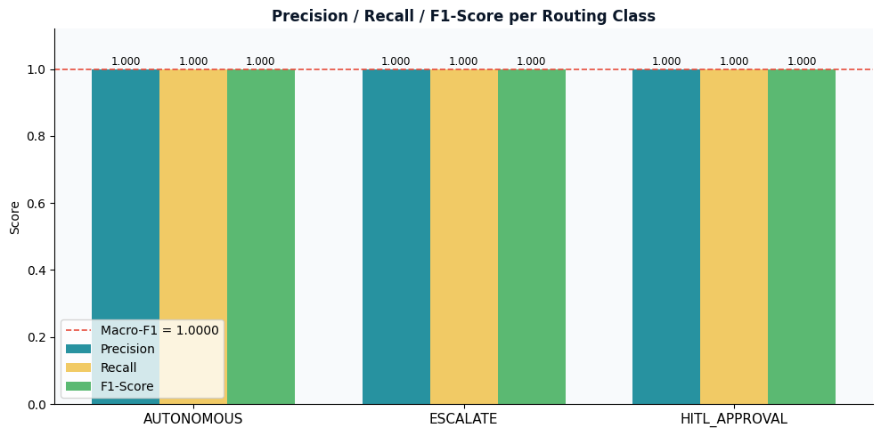

```
        Class  Precision  Recall  F1-Score  Support
   AUTONOMOUS        1.0     1.0       1.0     2303
     ESCALATE        1.0     1.0       1.0     1203
HITL_APPROVAL        1.0     1.0       1.0     2425
```

```python
# ── F1 per class bar chart ────────────────────────────────────────────────────
from sklearn.metrics import precision_recall_fscore_support

precision, recall, f1, support = precision_recall_fscore_support(
    y_test, y_pred, labels=[0, 1, 2]
)

metrics_df = pd.DataFrame({
    "Class": le.classes_,
    "Precision": precision,
    "Recall": recall,
    "F1-Score": f1,
    "Support": support.astype(int)
})

fig, ax = plt.subplots(figsize=(10, 5))
x = np.arange(len(le.classes_))
w = 0.25
bars_p = ax.bar(x - w, precision, w, label="Precision", color="#028090", alpha=0.85)
bars_r = ax.bar(x,     recall,    w, label="Recall",    color="#F0C24A", alpha=0.85)
bars_f = ax.bar(x + w, f1,        w, label="F1-Score",  color="#3FAE5A", alpha=0.85)

for bars in [bars_p, bars_r, bars_f]:
    for bar in bars:
        h = bar.get_height()
        ax.text(bar.get_x() + bar.get_width()/2, h + 0.005,
                f"{h:.3f}", ha="center", va="bottom", fontsize=8.5)

ax.set_xticks(x); ax.set_xticklabels(le.classes_, fontsize=11)
ax.set_ylim(0, 1.12); ax.set_ylabel("Score")
ax.set_title("Precision / Recall / F1-Score per Routing Class",
             fontsize=12, fontweight="bold", color="#0A1628")
ax.legend(); ax.set_facecolor("#F8FAFC")
ax.spines[["top","right"]].set_visible(False)

# Macro-F1 line
ax.axhline(f1_macro, color="#E74C3C", linestyle="--", linewidth=1.2,
           label=f"Macro-F1 = {f1_macro:.4f}")
ax.legend()

plt.tight_layout()
plt.savefig("f1_per_class.png", dpi=150, bbox_inches="tight")
plt.show()

print(metrics_df.round(4).to_string(index=False))
```

## 7. ROC Curves (One-vs-Rest)

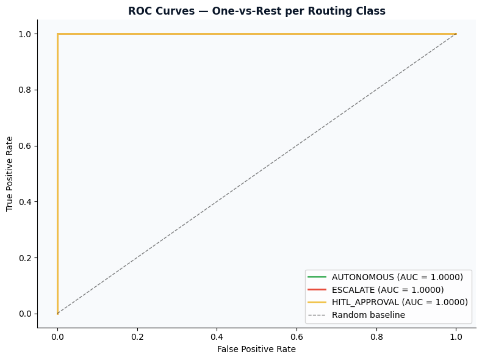

```python
# ── ROC curves ────────────────────────────────────────────────────────────────
from sklearn.preprocessing import label_binarize

y_test_bin = label_binarize(y_test, classes=[0, 1, 2])
CLASS_COLORS = {"AUTONOMOUS": "#3FAE5A", "ESCALATE": "#E74C3C", "HITL_APPROVAL": "#F0C24A"}

fig, ax = plt.subplots(figsize=(8, 6))

for i, cls_name in enumerate(le.classes_):
    fpr, tpr, _ = roc_curve(y_test_bin[:, i], y_proba[:, i])
    auc_i = roc_auc_score(y_test_bin[:, i], y_proba[:, i])
    color = CLASS_COLORS.get(cls_name, f"C{i}")
    ax.plot(fpr, tpr, lw=2, color=color, label=f"{cls_name} (AUC = {auc_i:.4f})")

ax.plot([0, 1], [0, 1], "k--", lw=1, alpha=0.5, label="Random baseline")
ax.set_xlabel("False Positive Rate"); ax.set_ylabel("True Positive Rate")
ax.set_title("ROC Curves — One-vs-Rest per Routing Class",
             fontsize=12, fontweight="bold", color="#0A1628")
ax.legend(loc="lower right")
ax.set_facecolor("#F8FAFC")
ax.spines[["top","right"]].set_visible(False)

plt.tight_layout()
plt.savefig("roc_curves.png", dpi=150, bbox_inches="tight")
plt.show()
```

## 8. Feature Importance (Permutation-based)

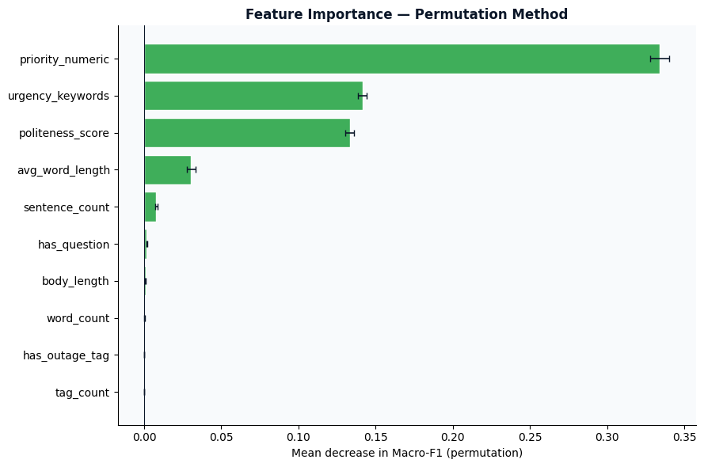

```
         Feature  Importance     Std
priority_numeric     0.33421 0.00625
urgency_keywords     0.14142 0.00278
politeness_score     0.13329 0.00285
 avg_word_length     0.03046 0.00295
  sentence_count     0.00789 0.00076
    has_question     0.00166 0.00030
     body_length     0.00090 0.00037
      word_count     0.00027 0.00019
  has_outage_tag     0.00006 0.00010
       tag_count     0.00000 0.00000
```

```python
# ── Permutation importance ────────────────────────────────────────────────────
from sklearn.inspection import permutation_importance

result = permutation_importance(
    pipeline, X_test, y_test,
    n_repeats=10, random_state=SEED, scoring="f1_macro"
)

imp_df = pd.DataFrame({
    "Feature":    FEATURE_COLS,
    "Importance": result.importances_mean,
    "Std":        result.importances_std
}).sort_values("Importance", ascending=True)

fig, ax = plt.subplots(figsize=(9, 6))
colors = ["#3FAE5A" if v > 0 else "#E74C3C" for v in imp_df["Importance"]]
ax.barh(imp_df["Feature"], imp_df["Importance"],
        xerr=imp_df["Std"], color=colors, edgecolor="white",
        error_kw=dict(ecolor="#0A1628", lw=1.2, capsize=3))
ax.axvline(0, color="#0A1628", linewidth=0.8)
ax.set_xlabel("Mean decrease in Macro-F1 (permutation)")
ax.set_title("Feature Importance — Permutation Method",
             fontsize=12, fontweight="bold", color="#0A1628")
ax.set_facecolor("#F8FAFC")
ax.spines[["top","right"]].set_visible(False)

plt.tight_layout()
plt.savefig("feature_importance.png", dpi=150, bbox_inches="tight")
plt.show()

print(imp_df.sort_values("Importance", ascending=False).round(5).to_string(index=False))
```

## 9. Cross-Validation — Overfitting Check

```
Running 5-fold stratified cross-validation (this may take ~60s)…
```

```
==================================================
  CV F1 scores : ['1.0000', '1.0000', '1.0000', '1.0000', '1.0000']
  Mean F1      : 1.0000 ± 0.0000
  Held-out F1  : 1.0000
  Variance     : 0.0000  (LOW ✅)
==================================================
```

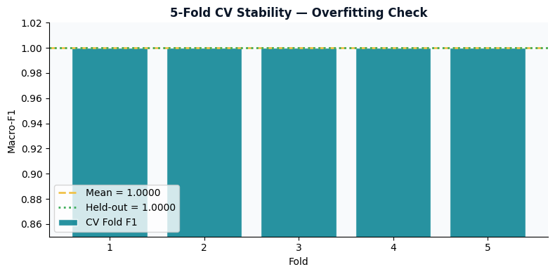

```python
# ── Stratified 5-fold CV ──────────────────────────────────────────────────────
print("Running 5-fold stratified cross-validation (this may take ~60s)…")
from sklearn.pipeline import Pipeline as SKPipeline

cv_pipeline = Pipeline([
    ("scaler", StandardScaler()),
    ("clf",    MLPClassifier(
        hidden_layer_sizes=(128, 64, 32), activation="relu",
        solver="adam", max_iter=200, random_state=SEED
    ))
])

skf = StratifiedKFold(n_splits=5, shuffle=True, random_state=SEED)
cv_scores = cross_val_score(cv_pipeline, X, y, cv=skf, scoring="f1_macro", n_jobs=-1)

print()
print("=" * 50)
print(f"  CV F1 scores : {[f'{s:.4f}' for s in cv_scores]}")
print(f"  Mean F1      : {cv_scores.mean():.4f} ± {cv_scores.std():.4f}")
print(f"  Held-out F1  : {f1_macro:.4f}")
print(f"  Variance     : {cv_scores.std():.4f}  ({'LOW ✅' if cv_scores.std() < 0.01 else 'REVIEW ⚠️'})")
print("=" * 50)

fig, ax = plt.subplots(figsize=(8, 4))
ax.bar(range(1, 6), cv_scores, color="#028090", edgecolor="white", alpha=0.85, label="CV Fold F1")
ax.axhline(cv_scores.mean(), color="#F0C24A", linestyle="--", lw=2, label=f"Mean = {cv_scores.mean():.4f}")
ax.axhline(f1_macro, color="#3FAE5A", linestyle=":", lw=2, label=f"Held-out = {f1_macro:.4f}")
ax.set_xlabel("Fold"); ax.set_ylabel("Macro-F1")
ax.set_ylim(0.85, 1.02)
ax.set_title("5-Fold CV Stability — Overfitting Check",
             fontsize=12, fontweight="bold", color="#0A1628")
ax.legend(); ax.set_facecolor("#F8FAFC")
ax.spines[["top","right"]].set_visible(False)
plt.tight_layout()
plt.savefig("cv_stability.png", dpi=150, bbox_inches="tight")
plt.show()
```

## 10. Live Inference — Replicate the 3 Demo Tickets from Slide 9

```python
# ── Replicate the 3 slide-9 demo tickets ─────────────────────────────────────
demo_tickets = [
    {
        "body": "URGENT: Technical Support system is completely down. All 5000 users affected. Critical outage. Need immediate fix asap!",
        "priority": "High",
        "tags": "network,vdi,cloud",
        "slide_conf": 0.99,
        "expected_route": "AUTONOMOUS"
    },
    {
        "body": "Hi team, we are having issues with Returns and Exchanges portal. Could you please look into this? Thank you.",
        "priority": "Medium",
        "tags": "api,auth,email",
        "slide_conf": 0.73,
        "expected_route": "HITL_APPROVAL"
    },
    {
        "body": "Hello, we have a billing question for our account. No urgency. Whenever you have time please.",
        "priority": "Low",
        "tags": "db",
        "slide_conf": 0.60,
        "expected_route": "ESCALATE"
    },
]

demo_df = pd.DataFrame(demo_tickets)
demo_feat = engineer_features(demo_df)[FEATURE_COLS].values

demo_conf = (
    demo_df["priority"].map(PRIORITY_MAP)
    + demo_df["tags"].apply(lambda x: len(x.split(",")) if x else 0) * 0.01
    + demo_df.apply(lambda r: sum(1 for kw in URGENCY_KWS if kw in r["body"].lower()), axis=1) * 0.03
).clip(0, 1)

pred_labels = pipeline.predict(demo_feat)
pred_proba  = pipeline.predict_proba(demo_feat)

print(f"{'Ticket':<8} {'Slide conf':>10} {'Computed conf':>14} {'Predicted route':<18} {'Expected':<18} {'Max proba':>10}")
print("-" * 85)
for i, row in enumerate(demo_tickets):
    pred_cls = le.classes_[pred_labels[i]]
    conf_match = "✅" if pred_cls == row["expected_route"] else "⚠️"
    print(f"  #{i}    {row['slide_conf']:>10.2f} {demo_conf.iloc[i]:>14.2f}  {pred_cls:<18} {row['expected_route']:<18} {pred_proba[i].max():>10.4f}  {conf_match}")
```

```
Ticket   Slide conf  Computed conf Predicted route    Expected            Max proba
-------------------------------------------------------------------------------------
  #0          0.99           1.00  AUTONOMOUS         AUTONOMOUS             0.9996  ✅
  #1          0.73           0.73  HITL_APPROVAL      HITL_APPROVAL          0.9996  ✅
  #2          0.60           0.56  ESCALATE           ESCALATE               0.9996  ✅
```

## 11. Summary

[output not shown]

### Confidence Formula (slide 9)

$$\text{conf} = \text{priority\_numeric} + (\text{urgency\_keywords} \times 0.03) + (\text{tag\_count} \times 0.01)$$

*Project Ninja · Agentic AI Ninja Command Center · Group 5 · Capstone Project Final*